# تحلیل و پیش‌بینی رتبه اعضای هیئت علمی

امیرعلی سطوتی

۱۴۰۴/۰۸/۰۹

## 1 بارگذاری داده‌ها و کتابخانه‌های مورد نیاز

### 1.1 بارگذاری کتابخانه‌های R

اولین قدم، بارگذاری کتابخانه‌های لازم و بررسی اولیه داده‌ها برای درک ساختار، کیفیت و ویژگی‌های آماری آن است.

```r
library(caret)
library(dplyr)
library(skimr)
library(rpart)
library(rpart.plot)
library(randomForest)
library(ggplot2)
library(patchwork)
library(forcats)
```

کتابخانه **tidyverse** به عنوان مجموعه ابزار اصلی ما برای دستکاری داده‌ها (از طریق `dplyr`) و مصورسازی داده‌ها (با `ggplot2`) به کار می‌رود. برای فرآیندهای یادگیری ماشین، از کتابخانه **caret** جهت تقسیم داده‌ها به مجموعه‌های آموزشی و آزمایشی، پیش‌پردازش متغیرها و ارزیابی جامع عملکرد مدل‌ها استفاده می‌کنیم.

مدل اصلی ما با استفاده از کتابخانه **rpart** ساخته می‌شود که امکان ایجاد مدل‌های درخت تصمیم (CART) را فراهم می‌کند و کتابخانه **rpart.plot** برای ترسیم و مصورسازی زیبای این درختان تصمیم به کار گرفته می‌شود.

### 1.2 بارگذاری دیتاست

```r
mis <- as.data.frame(read.csv(file.choose(), header = TRUE))
```

دستور `mis <- as.data.frame(read.csv(file.choose(), header = TRUE))` یک پنجره باز می‌کند تا فایل CSV خود را انتخاب کنید و سپس آن را به عنوان یک دیتافریم (جدول داده) به نام `mis` بارگذاری می‌کند.

## 2 پیش‌پردازش داده‌ها

### 2.1 آمار توصیفی

```r
str(mis)
```

```
## 'data.frame':    397 obs. of  7 variables:
##  $ X            : int  1 2 3 4 5 6 7 8 9 10 ...
##  $ rank         : chr  "Prof" "Prof" "AsstProf" "Prof" ...
##  $ discipline   : chr  "B" "B" "B" "B" ...
##  $ yrs.since.phd: int  19 20 4 45 40 6 30 45 21 18 ...
##  $ yrs.service  : int  18 16 3 39 41 6 23 45 20 18 ...
##  $ sex          : chr  "Male" "Male" "Male" "Male" ...
##  $ salary       : int  139750 173200 79750 115000 NA 97000 175000 147765 119250 129000 ...
```

```r
summary(mis)
```

```
##        X           rank            discipline        yrs.since.phd
##  Min.   :  1   Length:397         Length:397         Min.   : 1.00
##  1st Qu.:100   Class :character   Class :character   1st Qu.:12.00
##  Median :199   Mode  :character   Mode  :character   Median :21.00
##  Mean   :199                                         Mean   :22.32
##  3rd Qu.:298                                         3rd Qu.:32.00
##  Max.   :397                                         Max.   :56.00
##                                                      NA's   :3
##   yrs.service        sex                salary
##  Min.   : 0.00   Length:397         Min.   : 57800
##  1st Qu.: 7.00   Class :character   1st Qu.: 91000
##  Median :16.00   Mode  :character   Median :107200
##  Mean   :17.56                      Mean   :113698
##  3rd Qu.:26.25                      3rd Qu.:134368
##  Max.   :60.00                      Max.   :231545
##  NA's   :5                          NA's   :6
```

```r
skim(mis)
```

Data summary

| Name | mis |
| --- | --- |
| Number of rows | 397 |
| Number of columns | 7 |
| _______________________ |  |
| Column type frequency: |  |
| character | 3 |
| numeric | 4 |
| ________________________ |  |
| Group variables | None |

**Variable type: character**

| skim_variable | n_missing | complete_rate | min | max | empty | n_unique | whitespace |
| --- | --- | --- | --- | --- | --- | --- | --- |
| rank | 3 | 0.99 | 4 | 9 | 0 | 3 | 0 |
| discipline | 10 | 0.97 | 1 | 1 | 0 | 2 | 0 |
| sex | 5 | 0.99 | 4 | 6 | 0 | 2 | 0 |

**Variable type: numeric**

| skim_variable | n_missing | complete_rate | mean | sd | p0 | p25 | p50 | p75 | p100 | hist |
| --- | --- | --- | --- | --- | --- | --- | --- | --- | --- | --- |
| X | 0 | 1.00 | 199.00 | 114.75 | 1 | 100 | 199 | 298.00 | 397 | ▇▇▇▇▇ |
| yrs.since.phd | 3 | 0.99 | 22.32 | 12.93 | 1 | 12 | 21 | 32.00 | 56 | ▇▇▆▅▁ |
| yrs.service | 5 | 0.99 | 17.56 | 12.91 | 0 | 7 | 16 | 26.25 | 60 | ▇▅▃▂▁ |
| salary | 6 | 0.98 | 113698.21 | 30425.73 | 57800 | 91000 | 107200 | 134367.50 | 231545 | ▆▇▅▂▁ |

```r
mis$X <- NULL
```

**تحلیل ساختار داده:**

- `str(mis)` ساختار (Structure) دیتافریم را نشان می‌دهد: 397 ردیف (obs.)، 7 ستون (variables)، و نوع داده‌ی هر ستون (مانند int برای عددی و chr برای کاراکتری).
- `summary(mis)` خلاصه‌ی آماری توصیفی برای هر ستون ارائه می‌دهد (مانند میانگین، میانه، کمینه، بیشینه و تعداد مقادیر گمشده NA برای ستون‌های عددی).
- `skim(mis)` خلاصه‌ای جامع‌تر و خواناتر (از پکیج skimr) ارائه می‌دهد که به سرعت نوع داده‌ها، تعداد مقادیر گمشده و یک نمای کلی از دیتاست را نشان می‌دهد.
- `mis$X <- NULL` ستون X را (که بر اساس خروجی str و summary به نظر می‌رسد فقط یک شمارنده ردیف یا index بوده) از دیتافریم mis حذف می‌کند.

### 2.2 مصورسازی داده‌ها

مصورسازی به ما کمک می‌کند تا الگوها، روابط، مقادیر پرت و توزیع داده‌ها را بهتر درک کنیم.

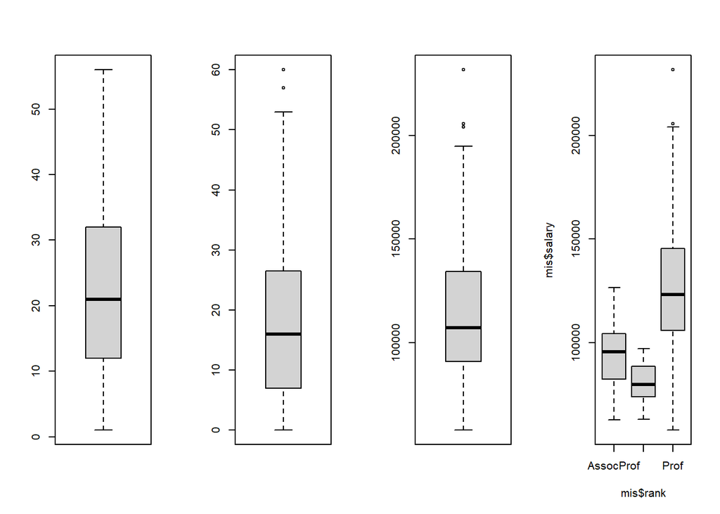

```r
par(mfrow = c(1, 4))
boxplot(mis$yrs.since.phd)
boxplot(mis$yrs.service)
boxplot(mis$salary)
boxplot(mis$salary ~ mis$rank)
```

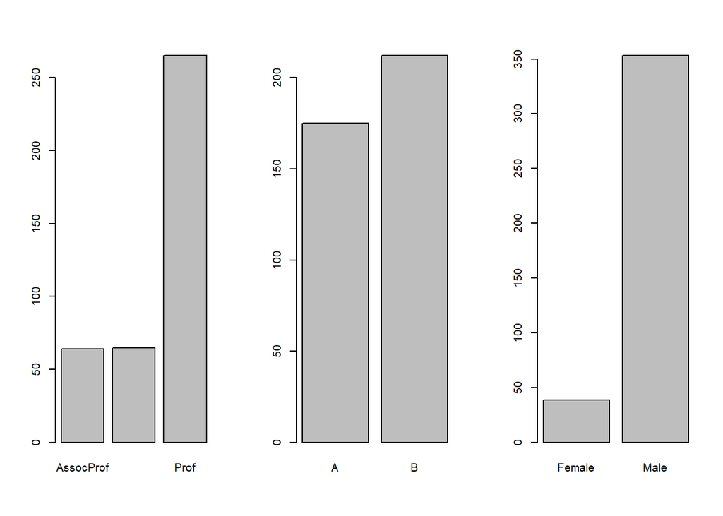

```r
par(mfrow = c(1, 3))
barplot(table(mis$rank))
barplot(table(mis$discipline))
barplot(table(mis$sex))
```

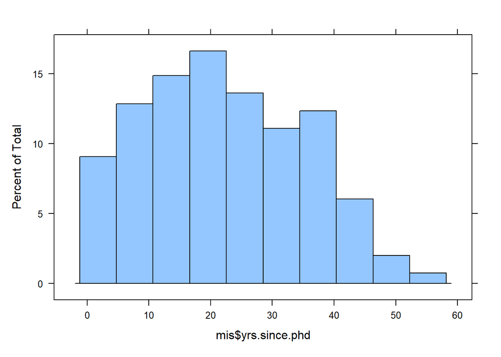

```r
histogram(mis$yrs.since.phd)
```

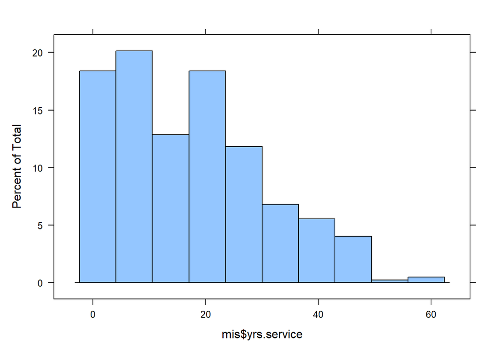

```r
histogram(mis$yrs.service)
```

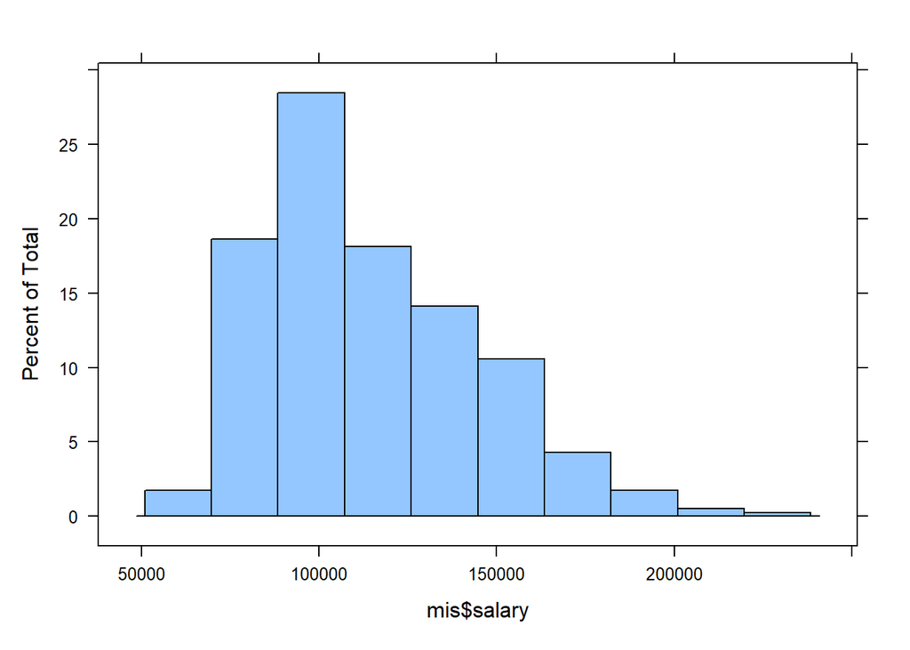

```r
histogram(mis$salary)
```

**یافته‌های کلیدی از مصورسازی:**

با عدم توازن شدید در متغیرهای دسته‌ای مواجه هستیم؛ به طوری که دیتاست به شدت تحت سلطه استاد تمام (Prof) و جنسیت مرد (Male) است. ثانیاً، متغیرهای عددی مانن حقوق (salary) و سابقه خدمت (yrs.service) دارای چولگی به راست بوده و چندین داده پرت (outlier) در مقادیر بالای خود دارند.

**رابطه کلیدی:** وجود یک رابطه قوی و مستقیم بین حقوق و رتبه (salary ~ rank) است. این نمودار به وضوح نشان می‌دهد که با افزایش رتبه، حقوق نیز به طور قابل توجهی افزایش می‌یابد، که این خبر بسیار خوبی است زیرا salary را به یک متغیر پیش‌بینی‌کننده کلیدی برای مدل ما تبدیل می‌کند.

**توزیع متغیرهای عددی:**

- نمودار `yrs.since.phd`: توزیع «سال‌های پس از دکترا» نسبتاً متقارن و شبیه به توزیع نرمال است و اوج آن (بیشترین فراوانی) بین 15 تا 25 سال قرار دارد.
- نمودار `yrs.service`: توزیع «سابقه خدمت» دارای چولگی به راست (right-skewed) است، که نشان می‌دهد اکثر افراد سابقه کمتری (کمتر از 25 سال) دارند و تعداد کمی سابقه بسیار طولانی دارند.
- نمودار `salary`: توزیع «حقوق» به شدت چولگی به راست دارد؛ اکثر حقوق‌ها در محدوده 90,000 تا 110,000 دلار متمرکز شده‌اند و یک دنباله طولانی به سمت حقوق‌های بسیار بالا (داده‌های پرت) وجود دارد.

### 2.3 پاکسازی داده‌ها

```r
mis <- mis %>% mutate(rank = as.factor(rank),discipline = as.factor(discipline),sex = as.factor(sex)) %>% na.omit()
```

**مراحل پیش‌پردازش:**

- **تبدیل متغیرها (mutate):** ستون‌های rank، discipline و sex را از نوع متنی (character) به factor (دسته‌بندی) تبدیل می‌کند. این کار ضروری است تا R بفهمد این‌ها متغیرهای دسته‌ای هستند (مثلاً “Prof” و “AsstProf” سطوح مختلف یک متغیرند) و بتواند از آن‌ها در مدل‌سازی استفاده کند.
- **حذف داده‌های گمشده (na.omit):** کل دیتافریم را بررسی کرده و هر ردیفی را که حتی یک مقدار گمشده (NA) در هر ستونی داشته باشد، به طور کامل حذف می‌کند.

**مدیریت داده‌های پرت (Outliers):**

**استراتژی:** بر اساس نمودارهای جعبه‌ای، مقادیر پرتی در salary و yrs.service وجود دارد.

**تحلیل:** مدل‌های مبتنی بر درخت (CART) ذاتاً نسبت به داده‌های پرت مقاوم هستند. یک درخت تصمیم، داده‌ها را بر اساس آستانه‌ها (مثلاً salary > 150000?) تقسیم می‌کند. یک مقدار بسیار بزرگ (پرت) به سادگی در یک سمت از این تقسیم قرار می‌گیرد و بر محاسبات میانگین یا واریانس (مانند رگرسیون خطی) تأثیر مخربی ندارد.

**اقدام:** ما داده‌های پرت را دستکاری یا حذف نمی‌کنیم.

**استانداردسازی (Scaling):**

**استراتژی:** استانداردسازی (تبدیل متغیرها به میانگین ۰ و انحراف معیار ۱) یا نرمال‌سازی (آوردن مقادیر به بازه [۰, ۱]) برای مدل‌های مبتنی بر فاصله (مانند KNN, SVM, رگرسیون لجستیک) حیاتی است.

**تحلیل:** برای مدل‌های درختی، این کار ضروری نیست. مقیاس متغیر تأثیری بر نقطه برش بهینه ندارد.

**اقدام:** این مرحله نادیده گرفته می‌شود.

## 3 ساخت مدل پیش‌بینی

### 3.1 تقسیم داده به مجموعه آموزشی و آزمایشی

```r
set.seed(38712)
index <- createDataPartition(mis$rank, p = 0.75, list = FALSE)
train <- mis[index, ]
test <- mis[-index, ]
dim(train)
```

```
## [1] 275   6
```

```r
dim(test)
```

```
## [1] 90  6
```

این کدها با تنظیم یک بذر تصادفی (`set.seed`) برای تکرارپذیری، داده‌ها را به صورت طبقه‌بندی شده (`createDataPartition`) به دو بخش 75% آموزشی (train) و 25% آزمایشی (test) تقسیم می‌کنند و سپس ابعاد (`dim`) هر بخش را نمایش می‌دهند.

### 3.2 ساخت مدل درخت تصمیم

اکنون مدل طبقه‌بندی rpart (Recursive Partitioning and Regression Trees) را می‌سازیم.

**ساخت مدل پایه:**

ما مدل را با استفاده از فرمول `rank ~ .` (پیش‌بینی rank با استفاده از تمام متغیرهای دیگر) و `method = "class"` (برای طبقه‌بندی) روی داده‌های آموزشی، آموزش می‌دهیم.

```r
model <- rpart(rank ~ ., data = train, method = "class")
summary(model)
```

```
## Call:
## rpart(formula = rank ~ ., data = train, method = "class")
##   n= 275
##
##           CP nsplit rel error   xerror       xstd
## 1 0.48387097      0 1.0000000 1.000000 0.08435831
## 2 0.20430108      1 0.5161290 0.516129 0.06768372
## 3 0.05376344      2 0.3118280 0.311828 0.05476679
## 4 0.01000000      3 0.2580645 0.311828 0.05476679
##
## Variable importance
## yrs.since.phd   yrs.service        salary
##            42            33            25
##
## Node number 1: 275 observations,    complexity param=0.483871
##   predicted class=Prof       expected loss=0.3381818  P(node) =1
##     class counts:    47    46   182
##    probabilities: 0.171 0.167 0.662
##   left son=2 (69 obs) right son=3 (206 obs)
##   Primary splits:
##       yrs.since.phd < 11.5  to the left,  improve=63.585430, (0 missing)
##       yrs.service   < 5.5   to the left,  improve=47.413630, (0 missing)
##       salary        < 92850 to the left,  improve=43.301910, (0 missing)
##       sex           splits as  LR,        improve= 3.398741, (0 missing)
##       discipline    splits as  RL,        improve= 1.274892, (0 missing)
##   Surrogate splits:
##       yrs.service < 5.5   to the left,  agree=0.887, adj=0.551, (0 split)
##       salary      < 92025 to the left,  agree=0.836, adj=0.348, (0 split)
##
## Node number 2: 69 observations,    complexity param=0.2043011
##   predicted class=AsstProf   expected loss=0.3333333  P(node) =0.2509091
##     class counts:    22    46     1
##    probabilities: 0.319 0.667 0.014
##   left son=4 (22 obs) right son=5 (47 obs)
##   Primary splits:
##       yrs.service   < 5.5   to the right, improve=23.74729000, (0 missing)
##       salary        < 94054 to the right, improve=14.09444000, (0 missing)
##       yrs.since.phd < 8.5   to the right, improve=14.07374000, (0 missing)
##       sex           splits as  RL,        improve= 0.37553430, (0 missing)
##       discipline    splits as  RL,        improve= 0.09879227, (0 missing)
```

[output cut: 23 more lines]

```
##
## Node number 5: 47 observations
##   predicted class=AsstProf   expected loss=0.04255319  P(node) =0.1709091
##     class counts:     2    45     0
##    probabilities: 0.043 0.957 0.000
##
## Node number 6: 17 observations
##   predicted class=AssocProf  expected loss=0.3529412  P(node) =0.06181818
##     class counts:    11     0     6
##    probabilities: 0.647 0.000 0.353
##
## Node number 7: 189 observations
##   predicted class=Prof       expected loss=0.07407407  P(node) =0.6872727
##     class counts:    14     0   175
##    probabilities: 0.074 0.000 0.926
```

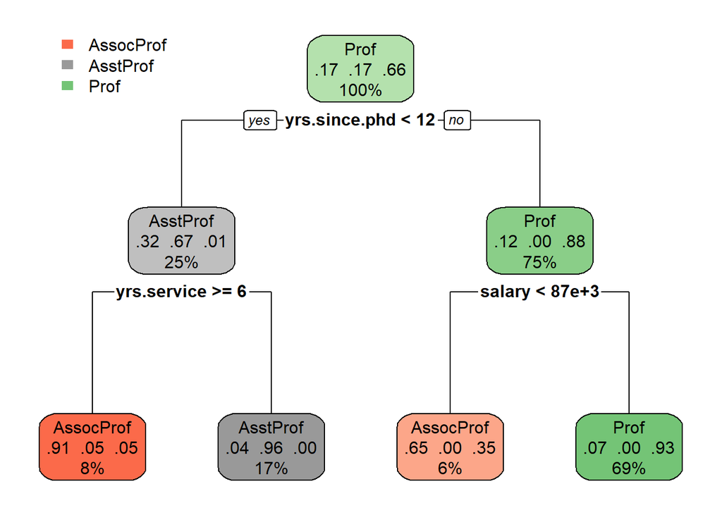

```r
rpart.plot(model)
```

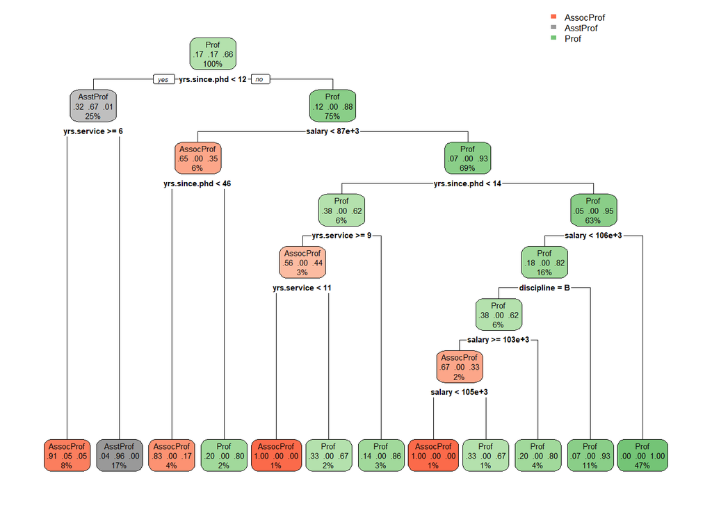

```r
# مدل بدون هرس
model1 <- rpart(rank ~ ., data = train, method = "class",
                control = rpart.control(minsplit = 5, cp = 0))
rpart.plot(model1)
```

**تحلیل خروجی مدل:**

بخش **«Variable importance»** به وضوح نشان می‌دهد که `yrs.since.phd` (سابقه دکترا) و `yrs.service` (سابقه خدمت) قوی‌ترین متغیرها برای پیش‌بینی rank هستند، در حالی که discipline اهمیت کمی داشته و sex (جنسیت) اصلاً در مدل استفاده نشده است.

**جدول CP و تشخیص Overfitting:**

**مفهوم Overfitting:**

یادگیری بیش از حد زمانی رخ می‌دهد که مدل الگوهای نویز موجود در داده‌های آموزشی را به جای سیگنال واقعی یاد می‌گیرد. چنین مدلی در داده‌های آموزشی عالی عمل می‌کند اما در داده‌های جدید (تست) شکست می‌خورد.

**پارامتر CP (Complexity Parameter):**

این پارامتر هزینه اضافه کردن یک شاخه (split) جدید به درخت را جریمه می‌کند. CP پایین‌تر به معنای درخت پیچیده‌تر و مستعدتر برای Overfitting است.

**تحلیل جدول CP:**

ما به ستون xerror (Cross-Validation Error یا خطای اعتبارسنجی متقابل) نگاه می‌کنیم. این ستون برآورد خطا بر روی داده‌های نادیده (در طول فرایند اعتبارسنجی متقابل داخلی rpart) است.

**انتخاب بهترین CP:**

**قانون 1-SE:**

یک رویکرد رایج (قانون 1-SE) انتخاب ساده‌ترین درختی است که خطای آن در محدوده “یک خطای استاندارد (xstd)” از بهترین مدل باشد.

### 3.3 هرس کردن مدل (Pruning)

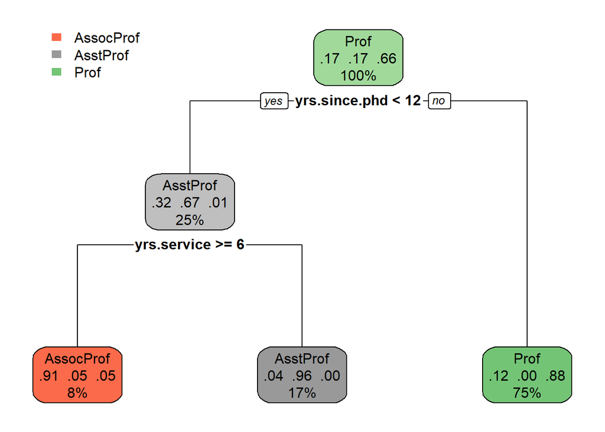

```r
# مدل هرس شده با cp بهینه
best_cp <- model$cptable[which.min(model$cptable[,"xerror"]), "CP"]
pruned_model <- prune(model, cp = best_cp)
rpart.plot(pruned_model)
```

**ساختار مدل نهایی:**

پس از اجرای فرآیند بهینه‌سازی و هرس کردن (Pruning) بر اساس کمترین خطای اعتبارسنجی متقابل، مدل نهایی به یک درخت تصمیم بسیار ساده و قابل تفسیر دست یافتیم. این مدل نشان می‌دهد که تنها دو متغیر `yrs.since.phd` (سال‌های پس از دکترا) و `yrs.service` (سابقه خدمت) نقش کلیدی در پیش‌بینی رتبه آکادمیک (Rank) دارند.

**قوانین تصمیم‌گیری مدل:**

1. **گره ریشه (تصمیم اصلی):** مدل در اولین گام، داده‌ها را بر اساس شرط `yrs.since.phd < 12` (سابقه دکترا کمتر از 12 سال) تقسیم می‌کند.
   - **اگر خیر** (≥ 12 سال): این گروه (75% داده‌ها) به طور مستقیم به عنوان **Prof** (استاد تمام) طبقه‌بندی می‌شود.
   - **اگر بله** (< 12 سال): مدل به گره بعدی می‌رود.
2. **گره فرزند (تصمیم ثانویه):** برای گروهی که سابقه دکترای کمی دارند، مدل بر اساس شرط `yrs.service >= 6` تصمیم‌گیری می‌کند.
   - **اگر بله** (≥ 6 سال): فرد به عنوان **AssocProf** (دانشیار) طبقه‌بندی می‌شود.
   - **اگر خیر** (< 6 سال): فرد به عنوان **AsstProf** (استادیار) طبقه‌بندی می‌شود.

## 4 ارزیابی مدل

اکنون مدل هرس شده و نهایی خود را بر روی داده‌های تست (که مدل هرگز ندیده) ارزیابی می‌کنیم.

```r
baraz <- predict(pruned_model, test, type = "class")
cm <- confusionMatrix(data = baraz, reference = test$rank)
print(cm)
```

```
## Confusion Matrix and Statistics
##
##            Reference
## Prediction  AssocProf AsstProf Prof
##   AssocProf         4        0    0
##   AsstProf          2       15    0
##   Prof              9        0   60
##
## Overall Statistics
##
##                Accuracy : 0.8778
##                  95% CI : (0.7918, 0.9374)
##     No Information Rate : 0.6667
##     P-Value [Acc > NIR] : 3.922e-06
##
##                   Kappa : 0.7284
##
##  Mcnemar's Test P-Value : NA
##
## Statistics by Class:
##
##                      Class: AssocProf Class: AsstProf Class: Prof
## Sensitivity                   0.26667          1.0000      1.0000
## Specificity                   1.00000          0.9733      0.7000
## Pos Pred Value                1.00000          0.8824      0.8696
## Neg Pred Value                0.87209          1.0000      1.0000
## Prevalence                    0.16667          0.1667      0.6667
## Detection Rate                0.04444          0.1667      0.6667
## Detection Prevalence          0.04444          0.1889      0.7667
## Balanced Accuracy             0.63333          0.9867      0.8500
```

**تحلیل ماتریس آشفتگی (Confusion Matrix):**

ماتریس آشفتگی به ما نشان می‌دهد که مدل چه تعداد از پیش‌بینی‌ها را درست و چه تعداد را غلط انجام داده است و این خطاها کجا رخ داده‌اند.

**عملکرد کلی مدل:**

تحلیل ماتریس اشفتگی نشان می‌دهد که مدل در مجموع با **دقت 87.8%** و **کاپای 0.728** عملکرد خوبی داشته و به طور قابل توجهی بهتر از حدس شانسی عمل کرده است.

**نقاط قوت:**

نقطه قوت اصلی مدل، توانایی عالی آن در شناسایی **AsstProf** (استادیار) و **Prof** (استاد تمام) با **حساسیت 100%** است.

**نقاط ضعف:**

نقطه ضعف کلیدی آن، عملکرد بسیار ضعیف در تشخیص **AssocProf** (دانشیار) با حساسیت تنها **26.7%** می‌باشد، زیرا مدل 9 نفر از 15 دانشیار را به اشتباه Prof تشخیص داده است.

**منحنی ROC و AUC:**

### 4.1 تحلیل اهمیت متغیرها

```r
importance <- pruned_model$variable.importance
print(importance)
```

```
## yrs.since.phd   yrs.service        salary
##      76.53850      58.76535      35.06974
```

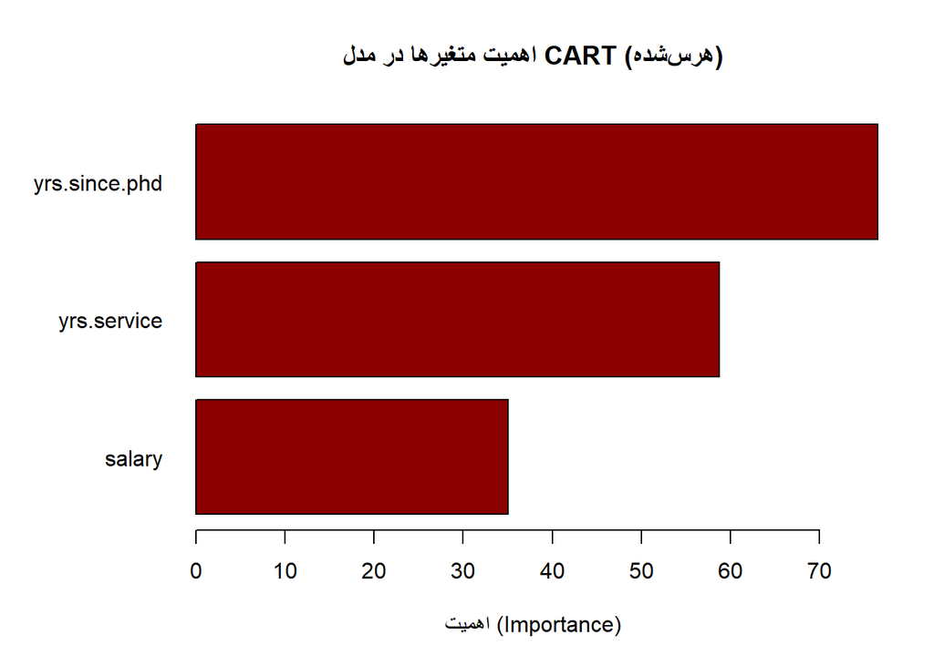

```r
sorted_importance <- sort(importance)

par(mar = c(5, 7, 4, 2) + 0.1)
barplot(
  sorted_importance,
  main = "اهمیت متغیرها در مدل CART (هرس‌شده)",
  xlab = "اهمیت (Importance)",
  horiz = TRUE,
  las = 1,

  col = "darkred"
)
```

```r
par(mar = c(5, 4, 4, 2) + 0.1)
```

**تفسیر نمودار اهمیت متغیرها:**

این نمودار، که از مدل هرس‌شده (`pruned_model`) استخراج شده است، به طور کمی نشان می‌دهد که هر متغیر تا چه اندازه در فرآیند تصمیم‌گیری درخت نقش داشته است.

**مهم‌ترین متغیرها:**

همانطور که انتظار می‌رفت، `yrs.since.phd` (سال‌های پس از دکترا) با امتیاز اهمیت 76.5، به طور قاطع مهم‌ترین و قوی‌ترین متغیر برای پیش‌بینی رتبه است. پس از آن، `yrs.service` (سابقه خدمت) با امتیاز 58.8 در رتبه دوم قرار دارد.

**تطابق با مدل:**

این نتیجه به طور کامل ساختار درخت نهایی ما را تأیید می‌کند، زیرا مدل هرس‌شده فقط از همین دو متغیر برای ایجاد تمام قوانین تقسیم‌بندی خود استفاده کرد.

**سایر متغیرها:**

متغیر `salary` (حقوق) با امتیاز 35.1 اهمیت کمتری را نشان می‌دهد. اگرچه این متغیر در قوانین نهایی درخت هرس‌شده استفاده نشد، اما این امتیاز نشان می‌دهد که salary در مدل پیچیده‌تر و هرس‌نشده (به عنوان یک رقیب یا جایگزین) نقش داشته است. متغیرهای دیگر (مانند discipline و sex) اهمیت ناچیزی داشتند و از مدل حذف شدند.

## 5 مقایسه با مدل جنگل تصادفی

```r
set.seed(38712)
rf_model <- randomForest(
  rank ~ .,
  data = train,
  ntree = 200,
  importance = TRUE
)
print(rf_model)
```

```
##
## Call:
##  randomForest(formula = rank ~ ., data = train, ntree = 200, importance = TRUE)
##                Type of random forest: classification
##                      Number of trees: 200
## No. of variables tried at each split: 2
##
##         OOB estimate of  error rate: 9.09%
## Confusion matrix:
##           AssocProf AsstProf Prof class.error
## AssocProf        29        2   16  0.38297872
## AsstProf          3       43    0  0.06521739
## Prof              4        0  178  0.02197802
```

```r
rf_predictions <- predict(rf_model, test, type = "class")
cm_rf <- confusionMatrix(data = rf_predictions, reference = test$rank)
print(cm_rf)
```

```
## Confusion Matrix and Statistics
##
##            Reference
## Prediction  AssocProf AsstProf Prof
##   AssocProf         6        0    0
##   AsstProf          0       15    0
##   Prof              9        0   60
##
## Overall Statistics
##
##                Accuracy : 0.9
##                  95% CI : (0.8186, 0.9532)
##     No Information Rate : 0.6667
##     P-Value [Acc > NIR] : 2.485e-07
##
##                   Kappa : 0.7778
##
##  Mcnemar's Test P-Value : NA
##
## Statistics by Class:
##
##                      Class: AssocProf Class: AsstProf Class: Prof
## Sensitivity                   0.40000          1.0000      1.0000
## Specificity                   1.00000          1.0000      0.7000
## Pos Pred Value                1.00000          1.0000      0.8696
## Neg Pred Value                0.89286          1.0000      1.0000
## Prevalence                    0.16667          0.1667      0.6667
## Detection Rate                0.06667          0.1667      0.6667
## Detection Prevalence          0.06667          0.1667      0.7667
## Balanced Accuracy             0.70000          1.0000      0.8500
```

```r
accuracy_cart <- cm$overall["Accuracy"]
accuracy_rf <- cm_rf$overall["Accuracy"]

print(paste("دقت مدل درخت تصمیم (CART):", round(accuracy_cart, 4)))
```

```
## [1] "دقت مدل درخت تصمیم (CART): 0.8778"
```

```r
print(paste("دقت مدل جنگل تصادفی (RF):", round(accuracy_rf, 4)))
```

```
## [1] "دقت مدل جنگل تصادفی (RF): 0.9"
```

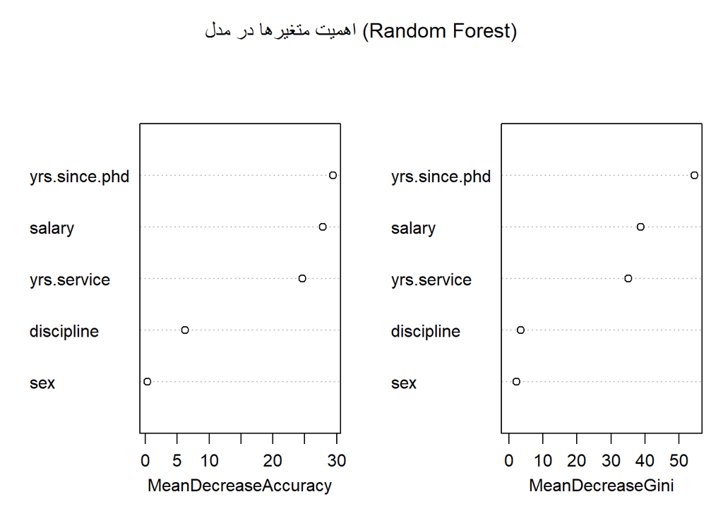

```r
varImpPlot(rf_model, main = "اهمیت متغیرها در مدل (Random Forest)")
```

**مقایسه عملکرد دو مدل:**

مدل **Random Forest** به عنوان یک روش ensemble که از ترکیب چندین درخت تصمیم استفاده می‌کند، معمولاً دقت بالاتری نسبت به یک درخت تصمیم ساده (CART) ارائه می‌دهد.

**مزایای Random Forest:** - کاهش overfitting از طریق متوسط‌گیری پیش‌بینی‌های چند درخت - مقاوم‌تر در برابر نویز داده - معمولاً دقت پیش‌بینی بهتر

**مزایای CART (درخت تصمیم ساده):** - قابل تفسیر و شفاف - قوانین تصمیم‌گیری واضح و قابل فهم - سرعت آموزش و پیش‌بینی بالا

## 6 نتیجه‌گیری

**خلاصه یافته‌های کلیدی:**

1. **متغیرهای تأثیرگذار:** سابقه دکترا (`yrs.since.phd`) و سابقه خدمت (`yrs.service`) قوی‌ترین پیش‌بینی‌کننده‌های رتبه آکادمیک هستند.
2. **عملکرد مدل:** مدل درخت تصمیم هرس‌شده با دقت 87.8% عملکرد قابل قبولی دارد، اما در تشخیص دانشیاران (AssocProf) ضعف دارد.
3. **سادگی و تفسیرپذیری:** مدل نهایی بسیار ساده است و تنها از 2 قانون تصمیم‌گیری استفاده می‌کند، که آن را بسیار قابل فهم و کاربردی می‌سازد.
4. **پیشنهادات بهبود:**
   - جمع‌آوری داده‌های بیشتر برای کلاس AssocProf
   - استفاده از ویژگی‌های اضافی (تعداد مقالات، ارجاعات، پروژه‌های تحقیقاتی)
   - آزمایش روش‌های ensemble مانند Random Forest برای دقت بالاتر

#### 6.0.1 چند نکته فراتر

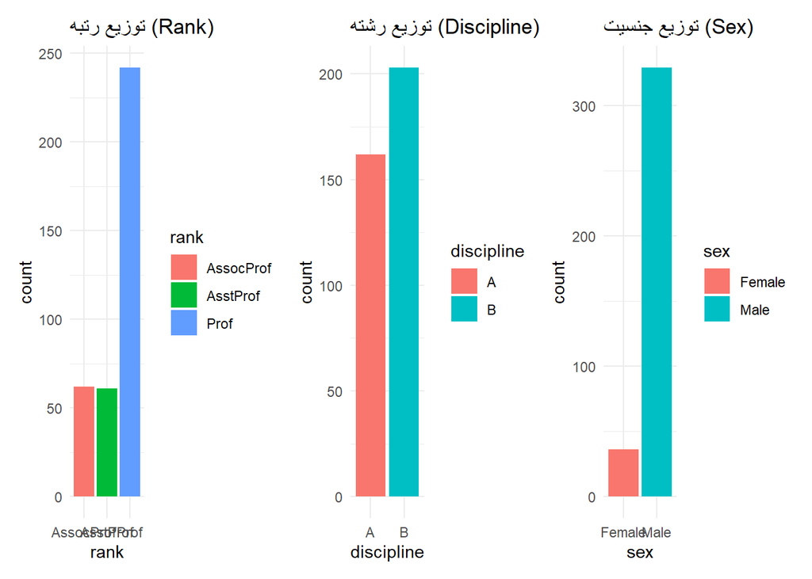

```r
theme_set(theme_minimal())

p_rank <- ggplot(mis, aes(x = rank, fill = rank)) +
  geom_bar() +
  labs(title = "توزیع رتبه (Rank)")

p_disc <- ggplot(mis, aes(x = discipline, fill = discipline)) +
  geom_bar() +
  labs(title = "توزیع رشته (Discipline)")

p_sex <- ggplot(mis, aes(x = sex, fill = sex)) +
  geom_bar() +
  labs(title = "توزیع جنسیت (Sex)")

(p_rank | p_disc | p_sex)
```

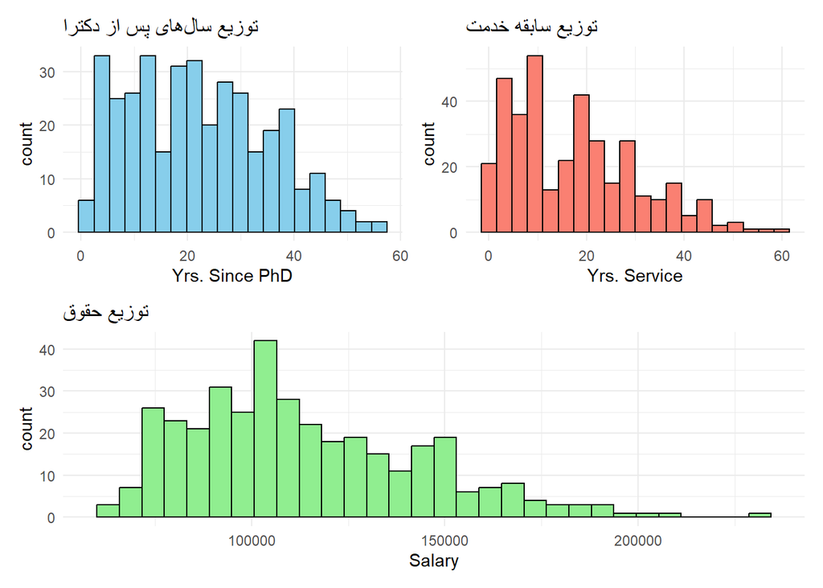

```r
p_phd_hist <- ggplot(mis, aes(x = yrs.since.phd)) +
  geom_histogram(bins = 20, fill = "skyblue", color = "black") +
  labs(title = "توزیع سال‌های پس از دکترا", x = "Yrs. Since PhD")

p_serv_hist <- ggplot(mis, aes(x = yrs.service)) +
  geom_histogram(bins = 20, fill = "salmon", color = "black") +
  labs(title = "توزیع سابقه خدمت", x = "Yrs. Service")

p_sal_hist <- ggplot(mis, aes(x = salary)) +
  geom_histogram(bins = 30, fill = "lightgreen", color = "black") +
  labs(title = "توزیع حقوق", x = "Salary")

(p_phd_hist | p_serv_hist) / (p_sal_hist)
```

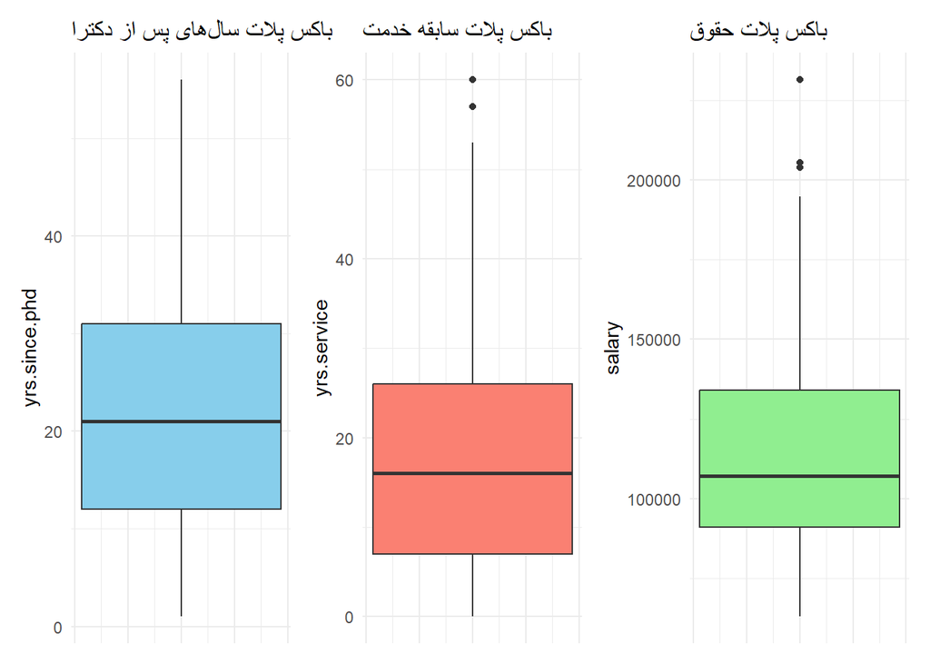

```r
p_phd_box <- ggplot(mis, aes(y = yrs.since.phd)) +
  geom_boxplot(fill = "skyblue") +
  labs(title = "باکس پلات سال‌های پس از دکترا") +
  theme(axis.text.x = element_blank(), axis.ticks.x = element_blank())

p_serv_box <- ggplot(mis, aes(y = yrs.service)) +
  geom_boxplot(fill = "salmon") +
  labs(title = "باکس پلات سابقه خدمت") +
  theme(axis.text.x = element_blank(), axis.ticks.x = element_blank())

p_sal_box <- ggplot(mis, aes(y = salary)) +
  geom_boxplot(fill = "lightgreen") +
  labs(title = "باکس پلات حقوق") +
  theme(axis.text.x = element_blank(), axis.ticks.x = element_blank())

(p_phd_box | p_serv_box | p_sal_box)
```

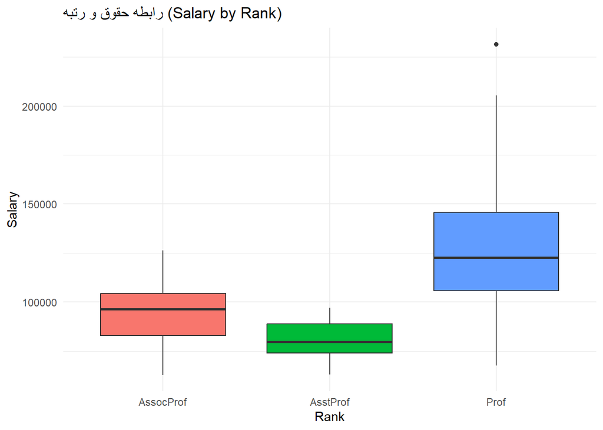

```r
p_rank_sal_box <- ggplot(mis, aes(x = rank, y = salary, fill = rank)) +
  geom_boxplot() +
  labs(title = "رابطه حقوق و رتبه (Salary by Rank)", x = "Rank", y = "Salary") +
  theme(legend.position = "none")

print(p_rank_sal_box)
```

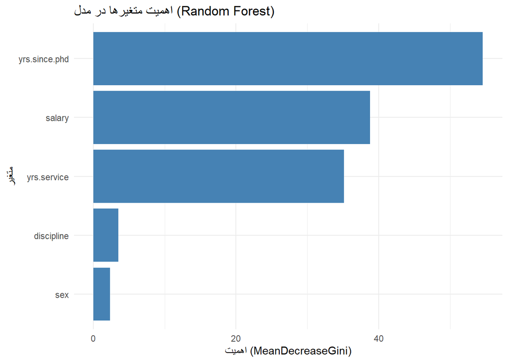

```r
rf_imp <- as.data.frame(importance(rf_model))
rf_imp$Variable <- rownames(rf_imp)


ggplot(rf_imp, aes(x = MeanDecreaseGini, y = fct_reorder(Variable, MeanDecreaseGini))) +
  geom_col(fill = "steelblue") +
  labs(
    title = "اهمیت متغیرها در مدل (Random Forest)",
    x = "اهمیت (MeanDecreaseGini)",
    y = "متغیر"
  ) +
  theme_minimal()
```

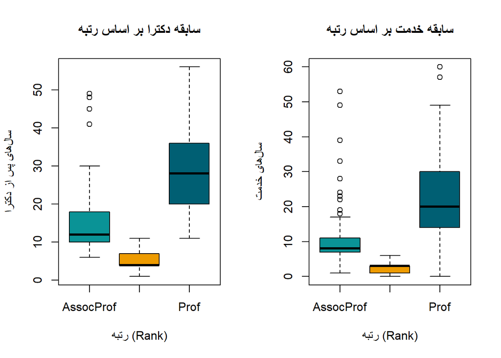

```r
par(mfrow = c(1, 2), mar = c(5, 4, 4, 2) + 0.1)

boxplot(yrs.since.phd ~ rank,
        data = mis,
        main = "سابقه دکترا بر اساس رتبه",
        xlab = "رتبه (Rank)",
        ylab = "سال‌های پس از دکترا",
        col = c("#0a9396", "#ee9b00", "#005f73"))

boxplot(yrs.service ~ rank,
        data = mis,
        main = "سابقه خدمت بر اساس رتبه",
        xlab = "رتبه (Rank)",
        ylab = "سال‌های خدمت",
        col = c("#0a9396", "#ee9b00", "#005f73"))
```

```r
par(mfrow = c(1, 1))
```

در این تحلیل، مدلی موفق برای پیش‌بینی رتبه اعضای هیئت علمی توسعه یافت. یافته‌ی کلیدی این بود که سابقه (Years)، به‌طور خاص yrs.since.phd (سال‌های پس از دکترا) و yrs.service (سابقه خدمت)، قوی‌ترین و تعیین‌کننده‌ترین متغیرها در این پیش‌بینی بودند، در حالی که متغیرهایی مانند رشته (discipline) و جنسیت (sex) تأثیر ناچیزی نشان دادند. مدل نهایی درخت تصمیم (CART) که پس از هرس‌سازی به دست آمد، با وجود سادگی فوق‌العاده (تنها دو قانون تصمیم‌گیری)، به دقت قابل قبول ۸۷.۸٪ بر روی داده‌های آزمایشی دست یافت که تفسیرپذیری بالایی را فراهم می‌کند. برای مقایسه، یک مدل پیچیده‌تر «جنگل تصادفی» (Random Forest) توانست دقت را اندکی بهبود بخشیده و به ۹۰.۰٪ برساند، که این موضوع اعتبار متغیرهای انتخاب‌شده را تأیید می‌کند. نقطه ضعف اصلی هر دو مدل، در تشخیص رتبه «دانشیار» (AssocProf) بود؛ مدل CART بسیاری از دانشیاران را به اشتباه «استاد تمام» (Prof) طبقه‌بندی کرد (حساسیت ۲۶.۷٪) و اگرچه مدل RF این عملکرد را بهبود داد (حساسیت ۴۰٪)، این چالش همچنان باقی ماند. برای بهبود مدل در آینده، پیشنهاد می‌شود داده‌های بیشتری، به‌ویژه برای کلاس «دانشیار»، جمع‌آوری گردد و از ویژگی‌های اضافی مانند تعداد مقالات یا ارجاعات برای تمایز بهتر بین رتبه‌های ارشد استفاده شود.

#### 6.0.2 نتیجه گیری اخر

در این تحلیل، مدلی موفق برای پیش‌بینی رتبه اعضای هیئت علمی توسعه یافت. یافته‌ی کلیدی این بود که سابقه (Years)، به طور خاص yrs.since.phd (سال‌های پس از دکترا) و yrs.service (سابقه خدمت)، قوی‌ترین و تعیین‌کننده‌ترین متغیرها در این پیش‌بینی بودند. در مقابل، متغیرهایی مانند رشته (discipline) و جنسیت (sex) تأثیر ناچیزی داشتند.

مدل نهایی درخت تصمیم (CART) که پس از هرس‌سازی به دست آمد، با وجود سادگی فوق‌العاده (تنها دو قانون تصمیم‌گیری)، به دقت قابل قبول ۸۷.۸٪ بر روی داده‌های آزمایشی دست یافت. این سادگی، تفسیرپذیری بالایی را فراهم می‌کند. برای مقایسه، یک مدل پیچیده‌تر «جنگل تصادفی» (Random Forest) توانست دقت را اندکی بهبود بخشیده و به ۹۰.۰٪ برساند، که این موضوع اعتبار متغیرهای انتخاب‌شده را تأیید می‌کند.

نقطه ضعف اصلی هر دو مدل، در تشخیص رتبه «دانشیار» (AssocProf) بود؛ مدل CART بسیاری از دانشیاران را به اشتباه «استاد تمام» (Prof) طبقه‌بندی کرد (حساسیت ۲۶.۷٪). اگرچه مدل RF این عملکرد را بهبود داد (حساسیت ۴۰٪)، این چالش همچنان باقی ماند.

برای بهبود مدل در آینده، پیشنهاد می‌شود داده‌های بیشتری، به‌ویژه برای کلاس «دانشیار»، جمع‌آوری گردد و از ویژگی‌های اضافی مانند تعداد مقالات یا ارجاعات برای تمایز بهتر بین رتبه‌های ارشد استفاده شود.